# Activity_Monitoring_Report

Ravi M.B

April 1, 2018

# Introduction

This report is written for elucidating the R script *activity_data_anlysis.R* written for *Course Project 1 of Reproducible Research*, the R script *activity_data_analysis.R* analyses the data from an anonymous individual personal activity monitoring device, this device as sugested on [CoursEra webpage](https://www.coursera.org/learn/reproducible-research/peer/gYyPt/course-project-1) collects data at 5 minute intervals through out the day.

The data consists of two months of data collected during the months of October and November, 2012 and include the number of steps taken in 5 minute intervals each day.

To finish the project,I have categorized the project in to tasks listed on CoursEra webpage they are described below

## Goal 1: Loading and Processing data

Variable names and the structure of the file are given by

```r
setwd("~/R/Reproducible_Research/Week2/CourseProject")
data_url <- "https://d396qusza40orc.cloudfront.net/repdata%2Fdata%2Factivity.zip"
data_activity <- "step_data.zip"
download.file(data_url, data_activity)
unzip(data_activity)
read_activity <- read.csv("activity.csv", sep = ",")
dim(read_activity)
```

```
## [1] 17568     3
```

```r
names(read_activity)
```

```
## [1] "steps"    "date"     "interval"
```

```r
head(read_activity)
```

```
##   steps       date interval
## 1    NA 2012-10-01        0
## 2    NA 2012-10-01        5
## 3    NA 2012-10-01       10
## 4    NA 2012-10-01       15
## 5    NA 2012-10-01       20
## 6    NA 2012-10-01       25
```

```r
tail(read_activity)
```

```
##       steps       date interval
## 17563    NA 2012-11-30     2330
## 17564    NA 2012-11-30     2335
## 17565    NA 2012-11-30     2340
## 17566    NA 2012-11-30     2345
## 17567    NA 2012-11-30     2350
## 17568    NA 2012-11-30     2355
```

```r
str(read_activity)
```

```
## 'data.frame':    17568 obs. of  3 variables:
##  $ steps   : int  NA NA NA NA NA NA NA NA NA NA ...
##  $ date    : Factor w/ 61 levels "2012-10-01","2012-10-02",..: 1 1 1 1 1 1 1 1 1 1 ...
##  $ interval: int  0 5 10 15 20 25 30 35 40 45 ...
```

after loding and processing the data missing values are ignored and mean of the total number of steps taken per day is evaluated as follows

```r
read_activity$date <- as.Date(read_activity$date)
clear_na_data <- subset(read_activity, !is.na(read_activity$steps))
total_steps_sum <-
  tapply(
    clear_na_data$steps,
    clear_na_data$date,
    sum,
    na.rm = TRUE,
    simplify = T
  )
```

histogram of the total number of steps taken each day is plotted using the below R script and also mean and median are calculated

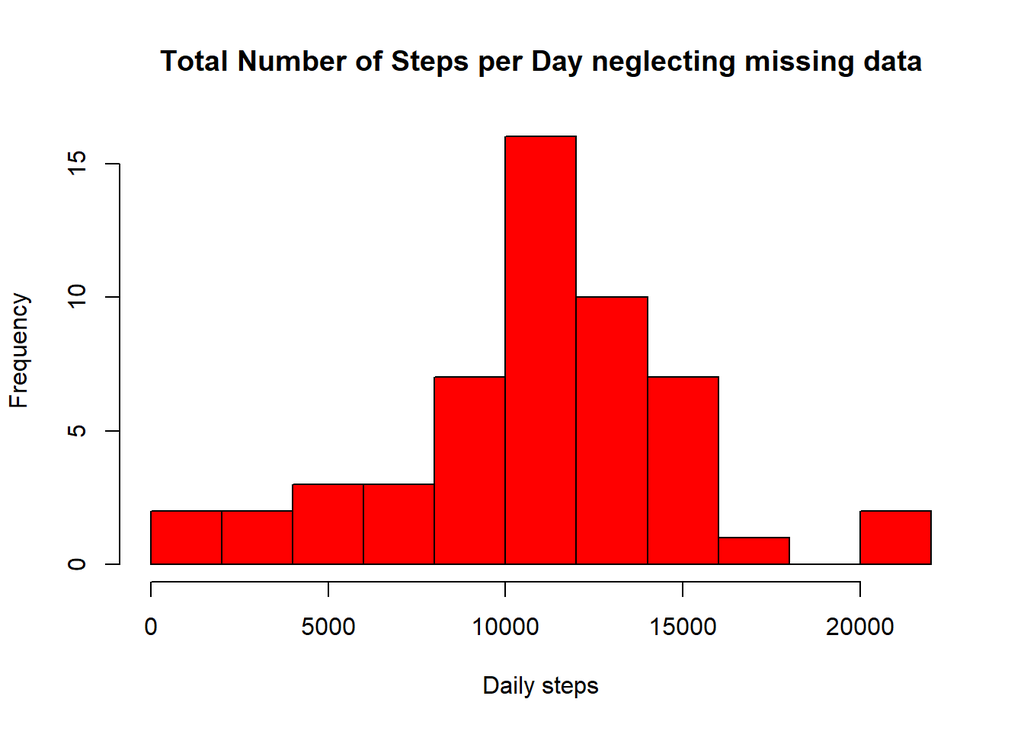

```r
hist(x=total_steps_sum,
     col="red",
     breaks=10,
     xlab="Daily steps",
     ylab="Frequency",
     main="Total Number of Steps per Day neglecting missing data")
```

```r
mean(total_steps_sum)
```

```
## [1] 10766.19
```

```r
median(total_steps_sum)
```

```
## [1] 10765
```

## Goal 2: Time series plot of Average daily activity pattern

I have costructed time series plot ** i.e type = *“l”* ** of the 5-minute interval (x-axis) and the average number of steps taken, averaged across all days (y-axis) also evaluated Which 5-minute interval, on average across all the days in the dataset, contains the maximum number of steps

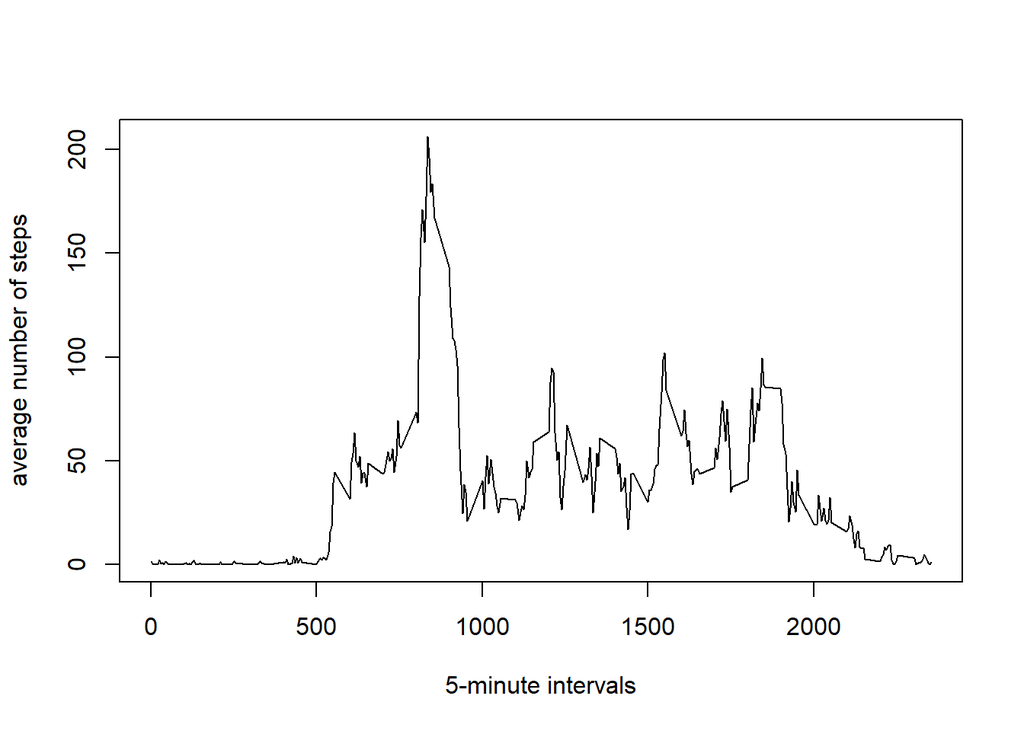

```r
avg_daily <- tapply(clear_na_data$steps, clear_na_data$interval, mean, na.rm=TRUE, simplify=T)
avg_daily_interval <- data.frame(interval=as.integer(names(avg_daily)), avg=avg_daily)
with(avg_daily_interval,
     plot(interval,
          avg,
          type="l",
          xlab="5-minute intervals",
          ylab="average number of steps"))
```

```r
max_num_steps <- max(avg_daily_interval$avg)
avg_daily_interval[avg_daily_interval$avg == max_num_steps, ]
```

```
##     interval      avg
## 835      835 206.1698
```

here *avg_daily_interval* and **_max_num_steps** variables were created to store the relevant results.

## Goal 3: Imputing missing values

Further a new data set which would consider or impute the missing values is costructed and the resulting data set evaluations are compared with the results where the missing values were neglected, the data from both the sets (missing values neglected and missing values imputed ) when compared it cold be inferred that mean and median were almost similar, please check the **ImputeData_MissingData.png** file

```r
nrow(read_activity[is.na(read_activity$steps),])
```

```
## [1] 2304
```

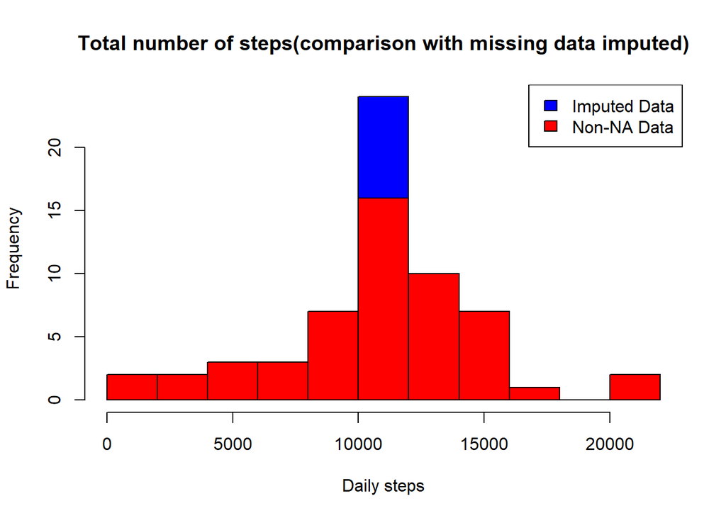

```r
impute_miss <- read_activity
na_data <- is.na(impute_miss$steps)
clear_na_avg <- tapply(clear_na_data$steps, clear_na_data$interval, mean, na.rm=TRUE, simplify=T)
impute_miss$steps[na_data] <- clear_na_avg[as.character(impute_miss$interval[na_data])]
new_data <- tapply(impute_miss$steps, impute_miss$date, sum, na.rm=TRUE, simplify=T)

hist(x=new_data,
     col="blue",
     breaks=10,
     xlab="Daily steps",
     ylab="Frequency",
     main="Total number of steps(comparison with missing data imputed)")


hist(x=total_steps_sum,
     col="red",
     breaks=10,
     xlab="Daily steps",
     ylab="Frequency",
     main="Total number of steps(comparison with missing data imputed)",
     add=T)
legend("topright", c("Imputed Data", "Non-NA Data"), fill=c("blue", "red") )
```

```r
mean(new_data)
```

```
## [1] 10766.19
```

```r
median(new_data)
```

```
## [1] 10766.19
```